# MSDS458_Assignment_02_20201212_v7

## MSDS458 Research Assignment 2

**More Technical**: Throughout the notebook. This types of boxes provide more technical details and extra references about what you are seeing. They contain helpful tips, but you can safely skip them the first time you run through the code.

The CIFAR-10 dataset (Canadian Institute For Advanced Research) is a collection of images that are commonly used to train machine learning and computer vision algorithms. It is one of the most widely used datasets for machine learning research. The CIFAR-10 dataset contains 60,000 32x32 color images in 10 different classes. The 10 different classes represent airplanes, cars, birds, cats, deer, dogs, frogs, horses, ships, and trucks. There are 6,000 images of each class.

## Import packages needed

```python
# Helper libraries
import datetime
from packaging import version
import matplotlib.pyplot as plt
import seaborn as sns

import sklearn
from sklearn.metrics import confusion_matrix
from collections import Counter
import numpy as np
import pandas as pd

# TensorFlow and tf.keras
import tensorflow as tf
from tensorflow import keras
from tensorflow.keras.utils import to_categorical
from tensorflow.keras import models, layers
from tensorflow.keras.models import Sequential
from tensorflow.keras.layers import Conv2D, MaxPooling2D
from tensorflow.keras.layers import Dropout, Flatten, Input, Dense
```

```python
%matplotlib inline
np.set_printoptions(precision=3, suppress=True)
```

### Verify TensorFlow Version and Keras Version

```python
print("This notebook requires TensorFlow 2.0 or above")
print("TensorFlow version: ", tf.__version__)
assert version.parse(tf.__version__).release[0] >=2
```

```
This notebook requires TensorFlow 2.0 or above
TensorFlow version:  2.4.1
```

```python
print("Keras version: ", keras.__version__)
```

```
Keras version:  2.4.0
```

**Suppress warning messages**

```python
def warn(*args, **kwargs):
    pass
import warnings
warnings.warn = warn
```

### Mount Google Drive to Colab Enviorment

```python
from google.colab import drive
drive.mount('/content/gdrive')
```

[output not shown]

## Loading cifar10 Dataset

The CIFAR-10 dataset consists of 60000 32x32 colour images in 10 classes, with 6000 images per class. There are 50000 training images and 10000 test images.

The dataset is divided into five training batches and one test batch, each with 10000 images. The test batch contains exactly 1000 randomly-selected images from each class. The training batches contain the remaining images in random order, but some training batches may contain more images from one class than another. Between them, the training batches contain exactly 5000 images from each class.

```python
(train_images, train_labels),(test_images, test_labels)= tf.keras.datasets.cifar10.load_data()
```

## EDA Training and Test Datasets

- Imported 50000 examples for training and 10000 examples for test
- Imported 50000 labels for training and 10000 labels for test

```python
print('train_images:\t{}'.format(train_images.shape))
print('train_labels:\t{}'.format(train_labels.shape))
print('test_images:\t\t{}'.format(test_images.shape))
print('test_labels:\t\t{}'.format(test_labels.shape))
```

```
train_images:	(50000, 32, 32, 3)
train_labels:	(50000, 1)
test_images:		(10000, 32, 32, 3)
test_labels:		(10000, 1)
```

### Review labels for training dataset

```python
print("First ten labels training dataset:\n {}\n".format(train_labels[0:10]))
print("This output the numeric label, need to convert to item description")
```

```
First ten labels training dataset:
 [[6]
 [9]
 [9]
 [4]
 [1]
 [1]
 [2]
 [7]
 [8]
 [3]]

This output the numeric label, need to convert to item description
```

### Plot Examples

```python
def get_three_classes(x, y):
    def indices_of(class_id):
        indices, _ = np.where(y == float(class_id))
        return indices

    indices = np.concatenate([indices_of(0), indices_of(1), indices_of(2)], axis=0)

    x = x[indices]
    y = y[indices]

    count = x.shape[0]
    indices = np.random.choice(range(count), count, replace=False)

    x = x[indices]
    y = y[indices]

    y = tf.keras.utils.to_categorical(y)

    return x, y
```

```python
(x_train, y_train), (x_test, y_test) = tf.keras.datasets.cifar10.load_data()
```

```python
x_preview, y_preview = get_three_classes(x_train, y_train)
x_preview, y_preview = get_three_classes(x_test, y_test)
```

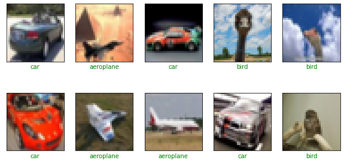

```python
class_names_preview = ['aeroplane', 'car', 'bird']

def show_random_examples(x, y, p):
    indices = np.random.choice(range(x.shape[0]), 10, replace=False)

    x = x[indices]
    y = y[indices]
    p = p[indices]

    plt.figure(figsize=(10, 5))
    for i in range(10):
        plt.subplot(2, 5, i + 1)
        plt.imshow(x[i])
        plt.xticks([])
        plt.yticks([])
        col = 'green' if np.argmax(y[i]) == np.argmax(p[i]) else 'red'
        plt.xlabel(class_names_preview[np.argmax(p[i])], color=col)
    plt.show()

show_random_examples(x_preview, y_preview, y_preview)
```

### Random Review of Examples

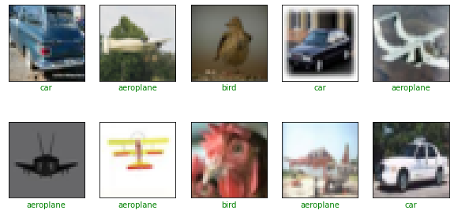

```python
show_random_examples(x_preview, y_preview, y_preview)
```

## Preprocessing Data for Model Development

| Label | Class_ |
| --- | --- |
| 0 | airplane |
| 1 | automobile |
| 2 | bird |
| 3 | cat |
| 4 | deer |
| 5 | dog |
| 6 | frog |
| 7 | horse |
| 8 | ship |
| 9 | truck |

```python
class_names = [['airplane'
,'automobile'
,'bird'
,'cat'
,'deer'
,'dog'
,'frog'
,'horse'
,'ship'
,'truck']]
```

### Preprocessing the Examples

1. Each element in each example is a pixel value
2. Pixel values range from 0 to 255
3. 0 = black
4. 255 = white

```python
train_images_norm = train_images.astype('float32')/255.
test_images_norm = test_images.astype('float32')/255.
```

```python
train_images_norm.shape, test_images_norm.shape
```

```
((50000, 32, 32, 3), (10000, 32, 32, 3))
```

## Validating our approach

10,000 samples of our training data to use as a validation set.

```python
val_images_norm, train_images_norm = train_images_norm[:10000], train_images_norm[10000:]
val_labels, train_labels = train_labels[:10000], train_labels[10000:]
```

```python
val_images_norm.shape, val_labels.shape
```

```
((10000, 32, 32, 3), (10000, 1))
```

```python
train_images_norm.shape, train_labels.shape
```

```
((40000, 32, 32, 3), (40000, 1))
```

## Create the Model

[figure not shown]

### Build CNN Model

```python
model = models.Sequential()
model.add(layers.Conv2D(filters=256, kernel_size=(3, 3), strides=(1, 1), activation=tf.nn.relu, input_shape=(32, 32, 3)))
model.add(layers.MaxPooling2D((2, 2),strides=2))
model.add(layers.Conv2D(filters=512, kernel_size=(3, 3), strides=(1, 1), activation=tf.nn.relu))
model.add(layers.MaxPooling2D(pool_size=(2, 2),strides=2))
model.add(layers.Conv2D(filters=1024, kernel_size=(3, 3), strides=(1, 1), activation=tf.nn.relu))
model.add(layers.MaxPooling2D(pool_size=(2, 2),strides=2))
model.add(layers.Flatten())
model.add(layers.Dense(units=512, activation=tf.nn.relu))
model.add(layers.Dense(units=10, activation=tf.nn.softmax))
```

```python
model.summary()
```

```
Model: "sequential_2"
_________________________________________________________________
Layer (type)                 Output Shape              Param #
=================================================================
conv2d_2 (Conv2D)            (None, 30, 30, 256)       7168
_________________________________________________________________
max_pooling2d_2 (MaxPooling2 (None, 15, 15, 256)       0
_________________________________________________________________
conv2d_3 (Conv2D)            (None, 13, 13, 512)       1180160
_________________________________________________________________
max_pooling2d_3 (MaxPooling2 (None, 6, 6, 512)         0
_________________________________________________________________
conv2d_4 (Conv2D)            (None, 4, 4, 1024)        4719616
_________________________________________________________________
max_pooling2d_4 (MaxPooling2 (None, 2, 2, 1024)        0
_________________________________________________________________
flatten_1 (Flatten)          (None, 4096)              0
_________________________________________________________________
dense (Dense)                (None, 512)               2097664
_________________________________________________________________
dense_1 (Dense)              (None, 10)                5130
=================================================================
Total params: 8,009,738
Trainable params: 8,009,738
Non-trainable params: 0
_________________________________________________________________
```

```python
keras.utils.plot_model(model, "CIFAR10.png", show_shapes=True)
```

```
('Failed to import pydot. You must `pip install pydot` and install graphviz (https://graphviz.gitlab.io/download/), ', 'for `pydotprint` to work.')
```

### Compiling the model

We also need to define a loss function. Think of this function as the difference between the predicted outputs and the actual outputs given in the dataset. This loss needs to be minimised in order to have a higher model accuracy. That's what the optimization algorithm essentially does - it minimises the loss during model training. For our multi-class classification problem, categorical cross entropy is commonly used.

Finally, we will use the accuracy during training as a metric to keep track of as the model trains.

**tf.keras.losses.SparseCategoricalCrossentropy**  
https://www.tensorflow.org/api_docs/python/tf/keras/losses/SparseCategoricalCrossentropy

```python
model.compile(optimizer='adam',
              loss=tf.keras.losses.SparseCategoricalCrossentropy(from_logits=False),
              metrics=['accuracy'])
```

## Training the model

**Module: tf.keras.callbacks**

**tf.keras.callbacks.EarlyStopping**  
https://www.tensorflow.org/api_docs/python/tf/keras/callbacks/EarlyStopping

**tf.keras.callbacks.ModelCheckpoint**  
https://www.tensorflow.org/api_docs/python/tf/keras/callbacks/ModelCheckpoint

```python
history = model.fit(train_images_norm
                    ,train_labels
                    ,epochs=20
                    ,batch_size=100
                    ,validation_data=(val_images_norm,val_labels)
                    ,callbacks=[
                    tf.keras.callbacks.EarlyStopping(monitor='val_accuracy', patience=2),
                    tf.keras.callbacks.ModelCheckpoint('/content/gdrive/My Drive/Colab Notebooks/model_{val_accuracy:.4f}.h5', save_best_only=True,
                                        save_weights_only=False, monitor='val_accuracy')]
                   )
```

```python
final = pd.DataFrame(history.history)
```

```python
final["Model"]='Model 0'
final
```

|  | loss | accuracy | val_loss | val_accuracy | Model |
| --- | --- | --- | --- | --- | --- |
| 0 | 1.574256 | 0.424925 | 1.207751 | 0.5637 | Model 0 |
| 1 | 1.104895 | 0.609450 | 0.992447 | 0.6452 | Model 0 |
| 2 | 0.894117 | 0.689375 | 0.972773 | 0.6572 | Model 0 |
| 3 | 0.734952 | 0.745575 | 0.829403 | 0.7058 | Model 0 |
| 4 | 0.601964 | 0.789225 | 0.819143 | 0.7230 | Model 0 |
| 5 | 0.484326 | 0.831000 | 0.792762 | 0.7308 | Model 0 |
| 6 | 0.369848 | 0.869825 | 0.838553 | 0.7299 | Model 0 |
| 7 | 0.263991 | 0.907025 | 0.992801 | 0.7269 | Model 0 |

### Validation Data

Data on which to evaluate the loss and any model metrics at the end of each epoch  
The model will not be trained on this data

## Evaluate the model

In order to ensure that this is not a simple "memorization" by the machine, we should evaluate the performance on the test set. This is easy to do, we simply use the `evaluate` method on our model.

```python
loss, accuracy = model.evaluate(test_images_norm, test_labels)
print('test set accuracy: ', accuracy * 100)
```

```
test set accuracy:  72.0300018787384
```

## Predictions

```python
preds = model.predict(test_images_norm)
print('shape of preds: ', preds.shape)
```

```
shape of preds:  (10000, 10)
```

## Plotting Performance Metrics

We use Matplotlib to create 2 plots--displaying the training and validation loss (resp. accuracy) for each (training) epoch side by side.

```python
history_dict = history.history
history_dict.keys()
```

```
dict_keys(['loss', 'accuracy', 'val_loss', 'val_accuracy'])
```

```python
history_df=pd.DataFrame(history_dict)
history_df.tail()
```

|  | loss | accuracy | val_loss | val_accuracy |
| --- | --- | --- | --- | --- |
| 3 | 0.734952 | 0.745575 | 0.829403 | 0.7058 |
| 4 | 0.601964 | 0.789225 | 0.819143 | 0.7230 |
| 5 | 0.484326 | 0.831000 | 0.792762 | 0.7308 |
| 6 | 0.369848 | 0.869825 | 0.838553 | 0.7299 |
| 7 | 0.263991 | 0.907025 | 0.992801 | 0.7269 |

```python
losses = history.history['loss']
accs = history.history['accuracy']
val_losses = history.history['val_loss']
val_accs = history.history['val_accuracy']
epochs = len(losses)
```

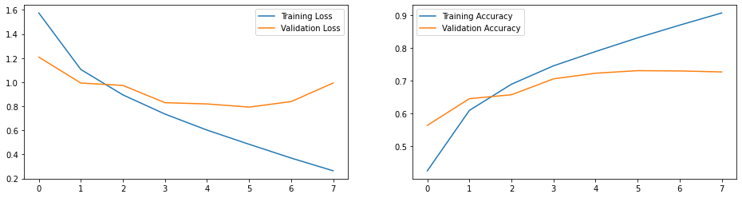

```python
plt.figure(figsize=(16, 4))
for i, metrics in enumerate(zip([losses, accs], [val_losses, val_accs], ['Loss', 'Accuracy'])):
    plt.subplot(1, 2, i + 1)
    plt.plot(range(epochs), metrics[0], label='Training {}'.format(metrics[2]))
    plt.plot(range(epochs), metrics[1], label='Validation {}'.format(metrics[2]))
    plt.legend()
plt.show()
```